# Storm Data Analysis

Endri Raco

4/6/2020

## Synopsis

This paper presents some insights regarding effects of storms and other severe weather events on both public health and economic problems for communities and municipalities. Many severe events can result in fatalities, injuries, and property damage, and preventing such outcomes to the extent possible is a key concern.

For this research we will explore U.S. National Oceanic and Atmospheric Administration’s (NOAA) storm database.The database covers the time period between 1950 and November 2011.

The research aims to address the following questions:

- Across the United States, which types of events are most harmful with respect to population health?
- Across the United States, which types of events have the greatest economic consequences?

## Introduction

Storms and other severe weather events can cause both public health and economic problems for communities and municipalities. Many severe events can result in fatalities, injuries, and property damage, and preventing such outcomes to the extent possible is a key concern.

This project involves exploring the U.S. National Oceanic and Atmospheric Administration’s (NOAA) storm database. This database tracks characteristics of major storms and weather events in the United States, including when and where they occur, as well as estimates of any fatalities, injuries, and property damage.

## Methods and Analysis

### Importing data

The data for this assignment come in the form of a comma-separated-value file compressed via the bzip2 algorithm to reduce its size.

You can download the file from the course web site:

[Storm Data [47Mb]](https://d396qusza40orc.cloudfront.net/repdata%2Fdata%2FStormData.csv.bz2)

Let’s start with data download. We copy link used in project description and assign it to **fileurl**.

```r
# We copy link used in project description and assign it to
# fileurl
filename <- "repdata_data_StormData.csv"
# Controll for already existing files If folder doesn't exist
# proceed with download
if (!file.exists(filename)) {
    fileURL <- "https://d396qusza40orc.cloudfront.net/repdata%2Fdata%2FStormData.csv.bz2"
    download.file(fileURL, filename, method = "curl")
}
# If file exists proceed with unzip
if (!file.exists("repdata_data_StormData.csv")) {
    unzip(filename)
}
```

Now we load our downloaded data:

```r
# Read repdata_data_StormData.csv
data <- read.csv("repdata_data_StormData.csv", sep = ",", header = TRUE,
    stringsAsFactors = FALSE)
names(data)
```

```
##  [1] "STATE__"    "BGN_DATE"   "BGN_TIME"   "TIME_ZONE"  "COUNTY"
##  [6] "COUNTYNAME" "STATE"      "EVTYPE"     "BGN_RANGE"  "BGN_AZI"
## [11] "BGN_LOCATI" "END_DATE"   "END_TIME"   "COUNTY_END" "COUNTYENDN"
## [16] "END_RANGE"  "END_AZI"    "END_LOCATI" "LENGTH"     "WIDTH"
## [21] "F"          "MAG"        "FATALITIES" "INJURIES"   "PROPDMG"
## [26] "PROPDMGEXP" "CROPDMG"    "CROPDMGEXP" "WFO"        "STATEOFFIC"
## [31] "ZONENAMES"  "LATITUDE"   "LONGITUDE"  "LATITUDE_E" "LONGITUDE_"
## [36] "REMARKS"    "REFNUM"
```

Let’s see how are data look like:

```r
# A first look to data
head(data)
```

```
##   STATE__           BGN_DATE BGN_TIME TIME_ZONE COUNTY COUNTYNAME STATE  EVTYPE
## 1       1  4/18/1950 0:00:00     0130       CST     97     MOBILE    AL TORNADO
## 2       1  4/18/1950 0:00:00     0145       CST      3    BALDWIN    AL TORNADO
## 3       1  2/20/1951 0:00:00     1600       CST     57    FAYETTE    AL TORNADO
## 4       1   6/8/1951 0:00:00     0900       CST     89    MADISON    AL TORNADO
## 5       1 11/15/1951 0:00:00     1500       CST     43    CULLMAN    AL TORNADO
## 6       1 11/15/1951 0:00:00     2000       CST     77 LAUDERDALE    AL TORNADO
##   BGN_RANGE BGN_AZI BGN_LOCATI END_DATE END_TIME COUNTY_END COUNTYENDN
## 1         0                                               0         NA
## 2         0                                               0         NA
## 3         0                                               0         NA
## 4         0                                               0         NA
## 5         0                                               0         NA
## 6         0                                               0         NA
##   END_RANGE END_AZI END_LOCATI LENGTH WIDTH F MAG FATALITIES INJURIES PROPDMG
```

[output cut: 20 more lines]

```r
# Let's check structure of dataframe
glimpse(data)
```

```
## Observations: 902,297
## Variables: 37
## $ STATE__    <dbl> 1, 1, 1, 1, 1, 1, 1, 1, 1, 1, 1, 1, 1, 1, 1, 1, 1, 1, 1,...
## $ BGN_DATE   <chr> "4/18/1950 0:00:00", "4/18/1950 0:00:00", "2/20/1951 0:0...
## $ BGN_TIME   <chr> "0130", "0145", "1600", "0900", "1500", "2000", "0100", ...
## $ TIME_ZONE  <chr> "CST", "CST", "CST", "CST", "CST", "CST", "CST", "CST", ...
## $ COUNTY     <dbl> 97, 3, 57, 89, 43, 77, 9, 123, 125, 57, 43, 9, 73, 49, 1...
## $ COUNTYNAME <chr> "MOBILE", "BALDWIN", "FAYETTE", "MADISON", "CULLMAN", "L...
## $ STATE      <chr> "AL", "AL", "AL", "AL", "AL", "AL", "AL", "AL", "AL", "A...
## $ EVTYPE     <chr> "TORNADO", "TORNADO", "TORNADO", "TORNADO", "TORNADO", "...
## $ BGN_RANGE  <dbl> 0, 0, 0, 0, 0, 0, 0, 0, 0, 0, 0, 0, 0, 0, 0, 0, 0, 0, 0,...
## $ BGN_AZI    <chr> "", "", "", "", "", "", "", "", "", "", "", "", "", "", ...
## $ BGN_LOCATI <chr> "", "", "", "", "", "", "", "", "", "", "", "", "", "", ...
## $ END_DATE   <chr> "", "", "", "", "", "", "", "", "", "", "", "", "", "", ...
## $ END_TIME   <chr> "", "", "", "", "", "", "", "", "", "", "", "", "", "", ...
```

[output cut: 24 more lines]

### Data Processing

We will focus to thosse observations related to injuries, fatalities, property damage and crop damage. Also we will turn variable names to lower case

```r
# Create df with focus data Name of variables in the lower
# case
df <- select(data, EVTYPE, FATALITIES, INJURIES, PROPDMG, PROPDMGEXP,
    CROPDMG, CROPDMGEXP) %>% rename_all(tolower)
names(df)
```

```
## [1] "evtype"     "fatalities" "injuries"   "propdmg"    "propdmgexp"
## [6] "cropdmg"    "cropdmgexp"
```

Next step is to understand variable type and check for missing values:

```r
# Let's check for the number of missing values
sum(is.na(df))
```

```
## [1] 0
```

```r
# We check classes of every column inside data
lapply(df, class)
```

```
## $evtype
## [1] "character"
##
## $fatalities
## [1] "numeric"
##
## $injuries
## [1] "numeric"
##
## $propdmg
## [1] "numeric"
##
## $propdmgexp
## [1] "character"
##
## $cropdmg
## [1] "numeric"
##
## $cropdmgexp
## [1] "character"
```

There are no missing values in the variables inside **df**. We have 3 variables of type **character** (evtype, propdmgexp, cropdmgexp).

For **evtype** we will clean cases from leading and trailing whitespaces and dublications to avoid problems with classification:

```r
# Clean evtype
df <- df %>% mutate(evtype = gsub(" +", " ", trimws(evtype)))
```

Let’s check if there are other symbols other than **K, M, B, H** inside variables **propdmgexp, cropdmgexp**

```r
# For variable propdmgexp
unique(df$propdmgexp)
```

```
##  [1] "K" "M" ""  "B" "+" "0" "5" "6" "?" "4" "2" "3" "H" "7" "-" "1" "8"
```

```r
# For variable crodmgexp
unique(df$cropdmgexp)
```

```
## [1] ""  "M" "K" "B" "?" "0" "2"
```

Let’s start process step by step.

```r
# Create 3 new variables and initiate them
df$propdmgcost = 0
df$cropdmgcost = 0
df$economy_damage_total = 0

# Let's fill new variable propdmgcost with data from recoding
# of propdmgexp
df[df$propdmgexp == "H", ]$propdmgcost = df[df$propdmgexp ==
    "H", ]$propdmg * 100
df[df$propdmgexp == "K", ]$propdmgcost = df[df$propdmgexp ==
    "K", ]$propdmg * 1000
df[df$propdmgexp == "M", ]$propdmgcost = df[df$propdmgexp ==
    "M", ]$propdmg * 1e+06
df[df$propdmgexp == "B", ]$propdmgcost = df[df$propdmgexp ==
    "B", ]$propdmg * 1e+09

# Let's fill new variable cropdmgcost with data from recoding
# of cropdmgexp
df[df$cropdmgexp == "H", ]$cropdmgcost = df[df$cropdmgexp ==
    "H", ]$cropdmg * 100
df[df$cropdmgexp == "K", ]$cropdmgcost = df[df$cropdmgexp ==
    "K", ]$cropdmg * 1000
df[df$cropdmgexp == "M", ]$cropdmgcost = df[df$cropdmgexp ==
    "M", ]$cropdmg * 1e+06
df[df$cropdmgexp == "B", ]$cropdmgcost = df[df$cropdmgexp ==
    "B", ]$cropdmg * 1e+09
# Total cost
df$totalcostdmg = df$propdmgcost + df$cropdmgcost
## Aggregate cost of damages
economic_effect <- df %>% select(evtype, totalcostdmg) %>% group_by(evtype) %>%
    summarise(costdmg = sum(totalcostdmg)) %>% arrange(desc(costdmg))
head(economic_effect, 10)
```

```
## # A tibble: 10 x 2
##    evtype                 costdmg
##    <chr>                    <dbl>
##  1 FLOOD             150319678250
##  2 HURRICANE/TYPHOON  71913712800
##  3 TORNADO            57340613590
##  4 STORM SURGE        43323541000
##  5 HAIL               18752904670
##  6 FLASH FLOOD        17562178610
##  7 DROUGHT            15018672000
##  8 HURRICANE          14610229010
##  9 RIVER FLOOD        10148404500
## 10 ICE STORM           8967041310
```

### Data Analysis

Now let’s see if we can answer to question about types of events (as indicated in the Evtype} variable) are most harmful with respect to population health across the United States ?

For this we aggregrate **fatalities** by **evtype** to calculate sums and see top values

```r
## Aggregate fatalities
agg_fatalities <- select(df, evtype, fatalities) %>% group_by(evtype) %>%
    summarise(sum_fatalities = sum(fatalities)) %>% arrange(desc(sum_fatalities))
head(agg_fatalities, 10)
```

```
## # A tibble: 10 x 2
##    evtype         sum_fatalities
##    <chr>                   <dbl>
##  1 TORNADO                  5633
##  2 EXCESSIVE HEAT           1903
##  3 FLASH FLOOD               978
##  4 HEAT                      937
##  5 LIGHTNING                 816
##  6 TSTM WIND                 504
##  7 FLOOD                     470
##  8 RIP CURRENT               368
##  9 HIGH WIND                 248
## 10 AVALANCHE                 224
```

Let’s visualize our numeric results regarding top fatalities:

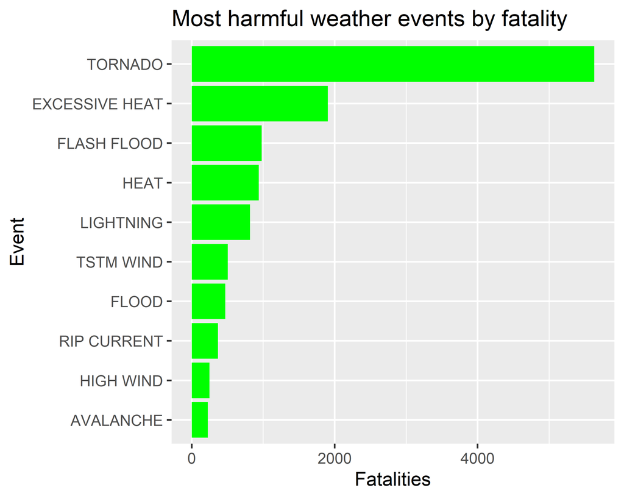

```r
## Plot top fatalities
top_fatalities <- ggplot(head(agg_fatalities, 10), aes(x = reorder(evtype,
    sum_fatalities), y = sum_fatalities)) + geom_bar(fill = "green",
    stat = "identity") + coord_flip() + ylab("Fatalities") +
    xlab("Event") + ggtitle("Most harmful weather events by fatality") +
    theme(legend.position = "none")
top_fatalities
```

Let’s repeat our previous steps for identifying top injuries

```r
## Aggregate injuries
agg_injuries <- select(df, evtype, injuries) %>% group_by(evtype) %>%
    summarise(sum_injuries = sum(injuries)) %>% arrange(desc(sum_injuries))
head(agg_injuries, 10)
```

```
## # A tibble: 10 x 2
##    evtype            sum_injuries
##    <chr>                    <dbl>
##  1 TORNADO                  91346
##  2 TSTM WIND                 6957
##  3 FLOOD                     6789
##  4 EXCESSIVE HEAT            6525
##  5 LIGHTNING                 5230
##  6 HEAT                      2100
##  7 ICE STORM                 1975
##  8 FLASH FLOOD               1777
##  9 THUNDERSTORM WIND         1488
## 10 HAIL                      1361
```

And the plot:

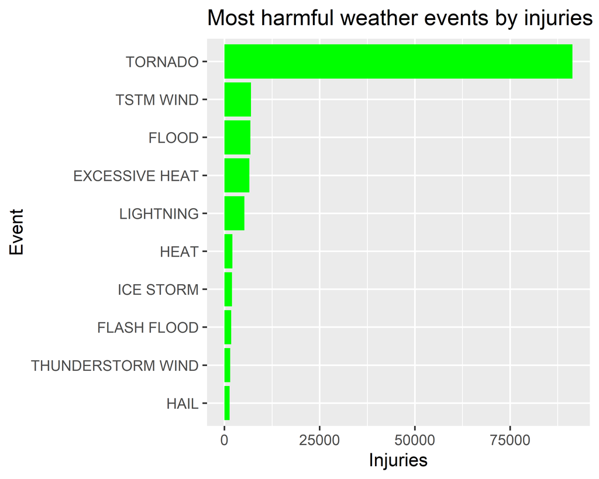

```r
## Plot top injuries
top_injuries <- ggplot(head(agg_injuries, 10), aes(x = reorder(evtype,
    sum_injuries), y = sum_injuries)) + geom_bar(fill = "green",
    stat = "identity") + coord_flip() + ylab("Injuries") + xlab("Event") +
    ggtitle("Most harmful weather events by injuries") + theme(legend.position = "none")
top_injuries
```

When it comes to economic consequences, We will vizualize top 10 factors judging by damages in dollars.

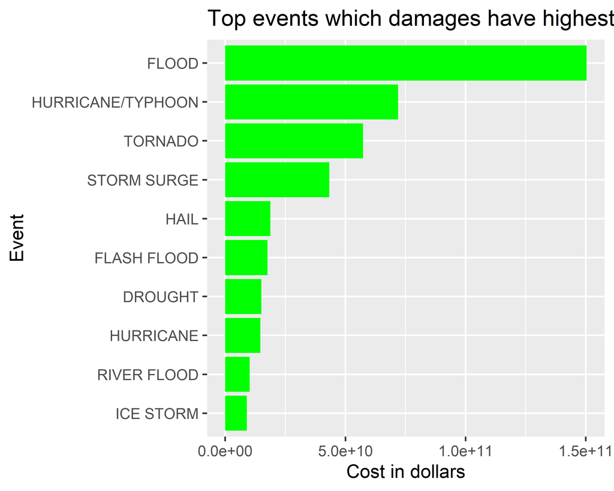

```r
## Plot top events which damages have highest cost
top_costdmg <- ggplot(head(economic_effect, 10), aes(x = reorder(evtype,
    costdmg), y = costdmg)) + geom_bar(fill = "green", stat = "identity") +
    coord_flip() + ylab("Cost in dollars") + xlab("Event") +
    ggtitle("Top events which damages have highest cost") + theme(legend.position = "none")
top_costdmg
```

Now let’s replot the above plot using logarithmic scale. We will put both plots in the same grid to compare if the used scale helps in inproving understanding.

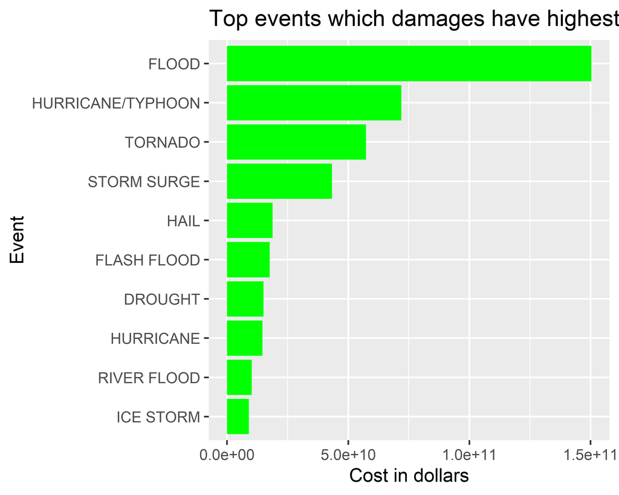

```r
## Plot top events which damages have highest cost
top_costdmg <- ggplot(head(economic_effect, 10), aes(x = reorder(evtype,
    costdmg), y = costdmg)) + geom_bar(fill = "green", stat = "identity") +
    coord_flip() + ylab("Cost in dollars") + xlab("Event") +
    ggtitle("Top events which damages have highest cost") + theme(legend.position = "none")
top_costdmg
```

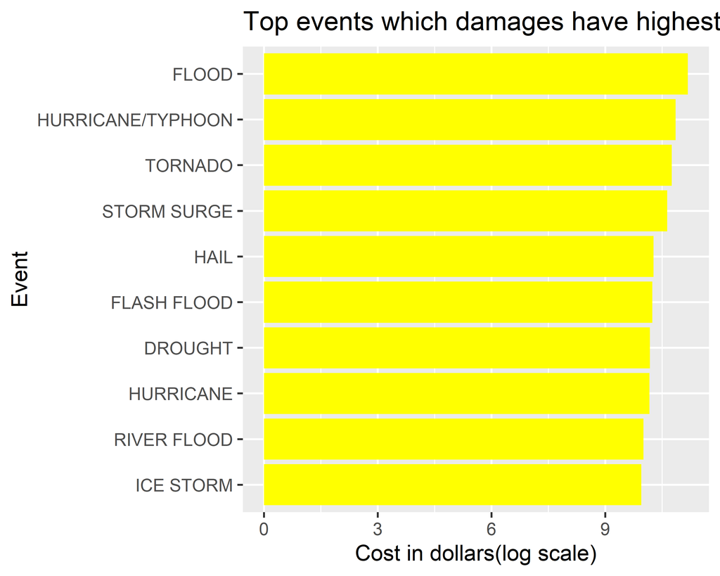

```r
## Plot the same plot using logarithmic scale
top_costdmg_log <- ggplot(head(economic_effect, 10), aes(x = reorder(evtype,
    costdmg), y = log10(costdmg))) + geom_bar(fill = "yellow",
    stat = "identity") + coord_flip() + ylab("Cost in dollars(log scale)") +
    xlab("Event") + ggtitle("Top events which damages have highest cost") +
    theme(legend.position = "none")
top_costdmg_log
```

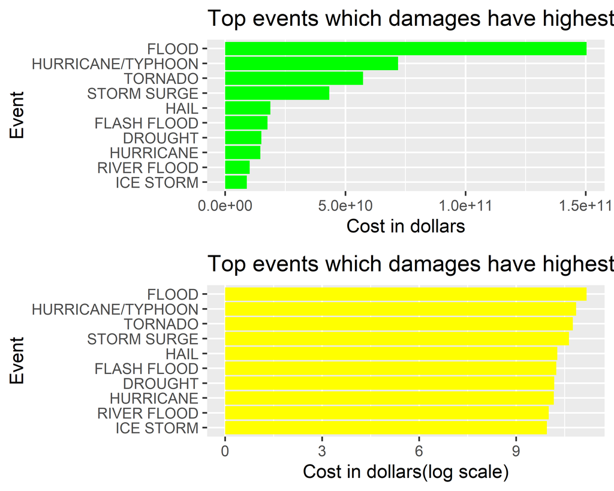

```r
## Arrange in grid
grid.arrange(top_costdmg, top_costdmg_log, ncol = 1, nrow = 2)
```

## Conclusions

Analysis shows that Tornados and Excessive Heat are the top weather events when it comes to fatalities.

Tornados are also the top weather event with respect to injuries. Suprising fact is that no matter how fatal can be Excessive Heat, this event is only in the fourth place when it comes to injuries, and is precedded by Thunderstorms and Flood.

Events that mostly affect economics and largest property damages are flood and hurricanes.